# Trabajo Final

Autor/a

Afiliación

Martín Ceriotti

Universidad Austral

## Trabajo Práctico Final de Análisis Inteligente de Datos.

Como hijo de productores agropecuarios, siempre estuve relacionado con la producción de distintos cultivos en la región central de la provincia de Santa Fe. Desde pequeño he visto como las distintas “variables” afectaban tanto la producción como el humor familiar.

El análisis que voy a realizar, es sobre la producción de soja, maíz y trigo en la República Argentina. Estos datos fueron descargados del sitio web de la Secretaría de Agricultura , Ganadería y Pesca https://datos.magyp.gob.ar “Secretaría de Agricultura , Ganadería y Pesca de la República Argentina”)

## Descripción de los datos

| Título de la columna | Tipo de dato | Descripción |
| --- | --- | --- |
| cultivo_nombre | Texto (string) | Nombre del cultivo. |
| anio | Número entero (integer) | Año al que corresponden los datos. |
| campania | Texto (string) | Campaña en la que se desarrollo el cultivo. |
| provincia_nombre | Texto (string) | Nombre de la provincia. |
| provincia_id | Texto (string) | Código de la provincia. |
| departamento_nombre | Texto (string) | Nombre del departamento. |
| departamento_id | Texto (string) | Código del departamento. |
| superficie_sembrada_ha | Número entero (integer) | Superficie sembrada en hectáreas. |
| superficie_cosechada_ha | Número entero (integer) | Superficie cosechada en hectáreas. |
| produccion_tm | Número entero (integer) | Producción en toneladas. |
| rendimiento_kgxha | Número entero (integer) | Rendimiento en kilos por hectárea. |

## Análisis Gráfico y Descriptivo Preliminar

|  | superficie_sembrada_ha | superficie_cosechada_ha | produccion_tm | rendimiento_kgxha |
| --- | --- | --- | --- | --- |
| N° de valores | 57519.00 | 56867.00 | 56867.00 | 56867.00 |
| N° de ceros | 5.00 | 1043.00 | 1059.00 | 1059.00 |
| N° de NA | 0.00 | 652.00 | 652.00 | 652.00 |
| Mínimo | 0.00 | 0.00 | 0.00 | 0.00 |
| Máximo | 894613.00 | 883613.00 | 3412500.00 | 33333.00 |
| Rango | 894613.00 | 883613.00 | 3412500.00 | 33333.00 |
| Suma | 1265538340.00 | 1145433611.00 | 3258414957.00 | 130276507.00 |
| Mediana | 4220.00 | 3500.00 | 6600.00 | 1769.00 |
| Media | 22002.09 | 20142.33 | 57298.87 | 2290.90 |
| Error estándar de la media | 204.04 | 197.66 | 656.21 | 7.54 |
| IC 95% de la media | 399.92 | 387.42 | 1286.17 | 14.78 |
| Varianza | 2394635897.27 | 2221873388.86 | 24487422836.29 | 3231990.66 |
| Desviación estándar | 48935.02 | 47136.75 | 156484.58 | 1797.77 |
| Coeficiente de variación | 2.22 | 2.34 | 2.73 | 0.78 |

### Correlaciones

Es de esperar que a las medidas estén correlacionadas dado que a mayor superficie sembrada se espera mayor produccion. La única que no está correlacionada es el rendimiento por ha.

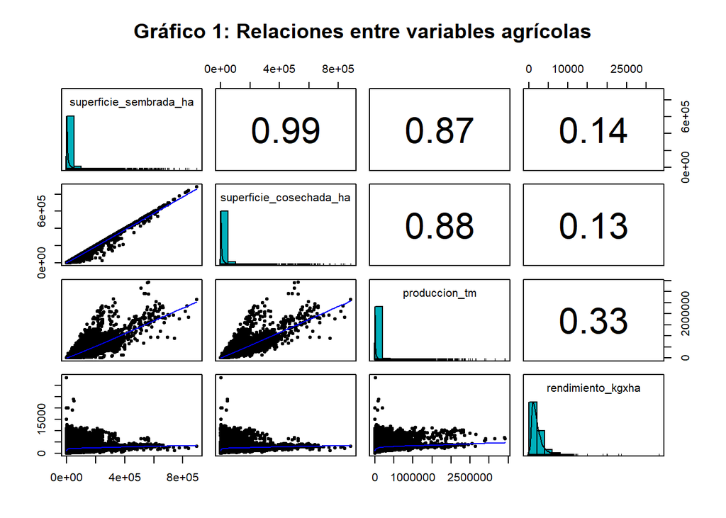

### BoxPlot

Hay gran variabilidad en los datos, ya que hay muchos departamentos de variado tamaño, con superficies y rindes de todo tipo.

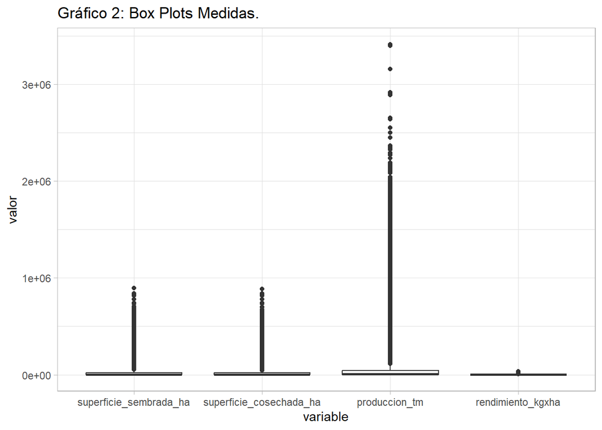

## Gráficos y Grillas.

### Evolución de la siembra de los cultivos desde 1947 a 2023.

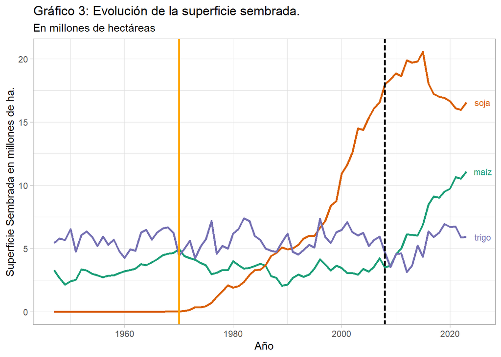

**1970:** Comienzo de la siembra directa en Argentina (fuente: Aapresid - Asociación Argentina de Productores en Siembra Directa).

**2008:** Inicio del conflicto entre el gobierno nacional y los productores agropecuarios.

En el caso del trigo, la serie se mantiene relativamente estable. Para el maíz podemos notar que en 2008, se comienza a elegir este cultivo con menos retenciones en lugar de la soja.

### Superficie histórica sembrada por provincia y cultivo.

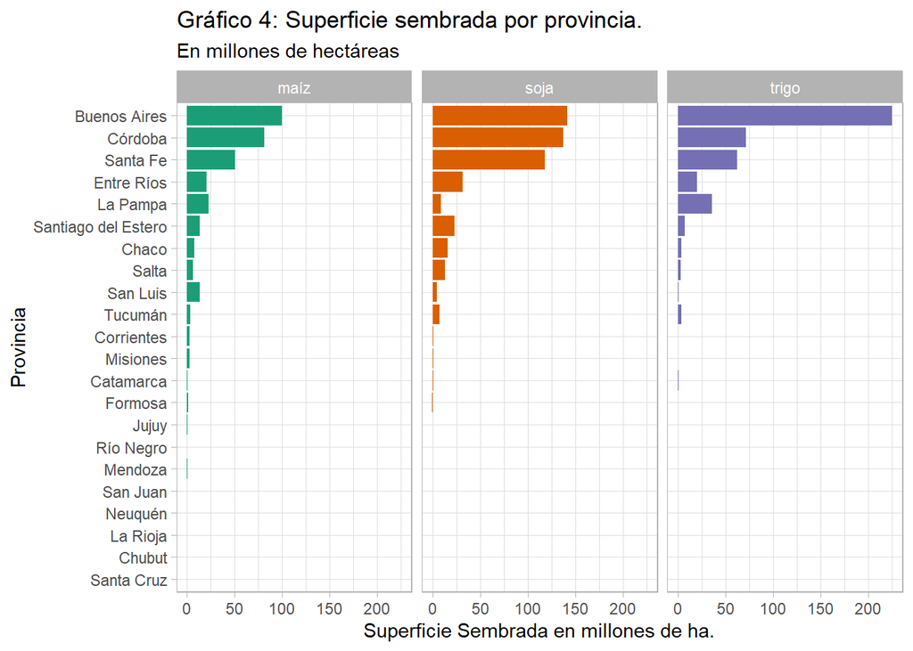

Las provincias de mayor producción de los cultivos en estudio son Buenos Aires, Córdoba, Santa Fe, Entre Ríos y La Pampa.

### Mejores Rindes Históricos.

| anio | provincia_nombre | departamento_nombre | cultivo_nombre | rendimiento_kgxha |
| --- | --- | --- | --- | --- |
| 1994 | Tucumán | Famaillá | maíz | 33333 |
| 1960 | Santa Fe | Rosario | maíz | 23700 |
| 1964 | Córdoba | Tercero Arriba | maíz | 23000 |
| 1985 | Santa Fe | Vera | soja | 20000 |
| 2011 | Córdoba | San Alberto | soja | 19902 |
| 1953 | Buenos Aires | Junín | trigo | 19000 |
| 2013 | Catamarca | El Alto | maíz | 14933 |
| 2018 | San Luis | Ayacucho | maíz | 12500 |
| 2020 | San Luis | Ayacucho | maíz | 12200 |
| 1948 | Santa Fe | San Justo | maíz | 12000 |

**Rendimientos en Maíz** De acuerdo al *Récord mundial Guinness*, el rendimiento máximo histórico de maíz, se dió en Virginia, EE. UU. en el año 2023. El rendimiento fue alrededor de 38 toneladas por hectárea. Dicho esto, es probable que los datos históricos que se tienen para Maiz deban ser revisados.

### Mejores Campañas de la historia.

| campania | produccion_tm |
| --- | --- |
| 2018/2019 | 131584322 |
| 2019/2020 | 126953165 |
| 2021/2022 | 125048532 |
| 2020/2021 | 124387993 |
| 2016/2017 | 122857978 |
| 2023/2024 | 121560870 |
| 2015/2016 | 110203053 |
| 2014/2015 | 109145803 |
| 2017/2018 | 99766295 |
| 2013/2014 | 95674224 |

De acuerdo a estimaciones de la bolsa de comercio de Rosario, la campaña 2025/2026 será record en cosecha de trigo, con una marca histórica record.

[Cosecha Record de Trigo](https://www.lanacion.com.ar/economia/campo/megacampana-confirmaron-que-la-argentina-tendra-la-mayor-cosecha-de-trigo-de-la-historia-nid12112025/)

### Peores Campañas de la historia.

| campania | produccion_tm |
| --- | --- |
| 1951/1952 | 4140666 |
| 1949/1950 | 5980842 |
| 1950/1951 | 8466674 |
| 1948/1949 | 8650362 |
| 1960/1961 | 9050957 |
| 1955/1956 | 9120515 |
| 1956/1957 | 9799430 |
| 1959/1960 | 9945831 |
| 1962/1963 | 10078920 |
| 1954/1955 | 10236483 |

Podemos apreciar “outliers” planteados en la tabla de mejores rendimientos históricos, probablemente por fallas en la medición o carga de los datos antiguos.

#### Trigo.

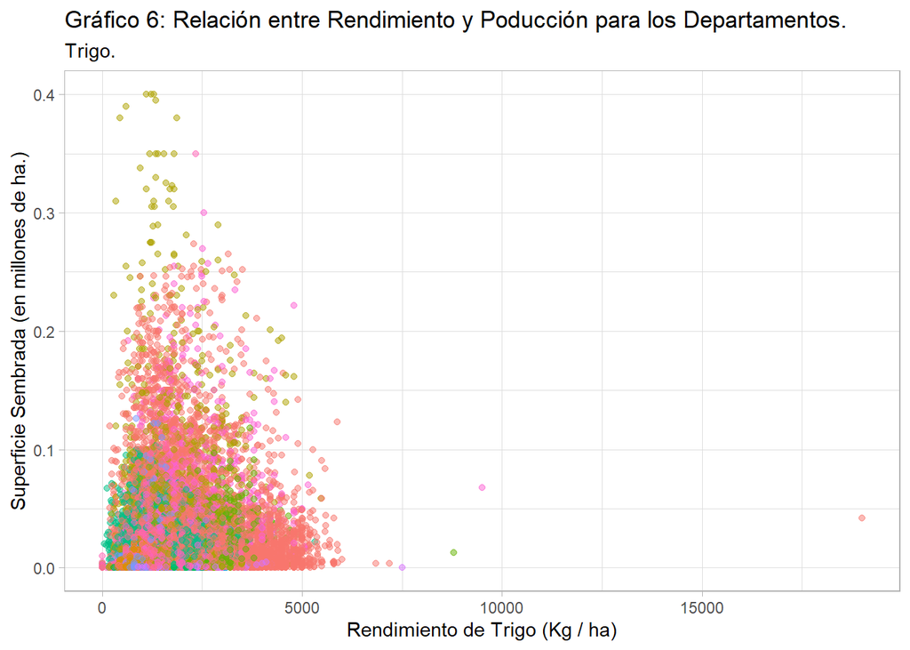

#### Maíz.

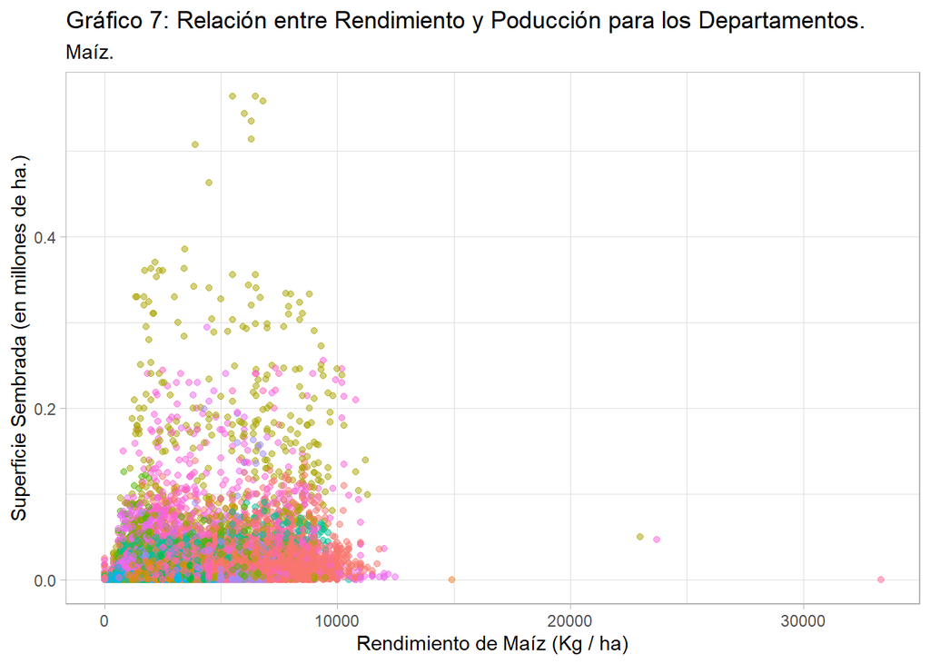

#### Soja

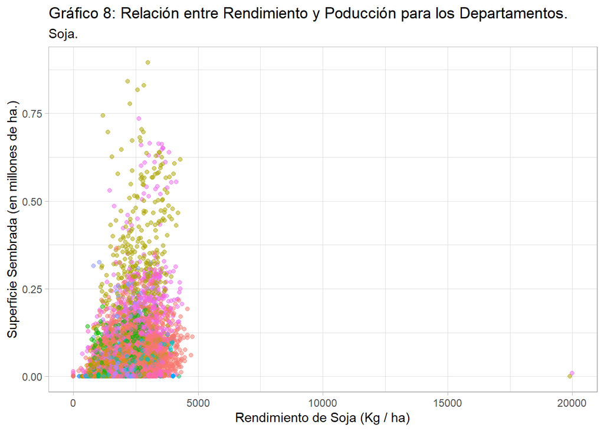

En una primera versión, use plotly, pero generaba un hltm demasiado pesado. Graficando con ggplot directamente se puede ver el punto marcado con un html liviano.

## Tratamiento de los Outliers.

Para un análisis complementario, quito los outliers del set de datos y vuelvo a generar los dot plots.

Para ello, calculo el primer y tercer cuartil, luego quito los registros que esté por debajo de Q1 - 1.5 IQR o por encima de Q3 + 1.5 IQR:

$$IQR = Q3 - Q1$$

$$rendimiento_kgxha < q1 - 1.5 * IQR$$

$$rendimiento_kgxha > q3 + 1.5 * IQR$$

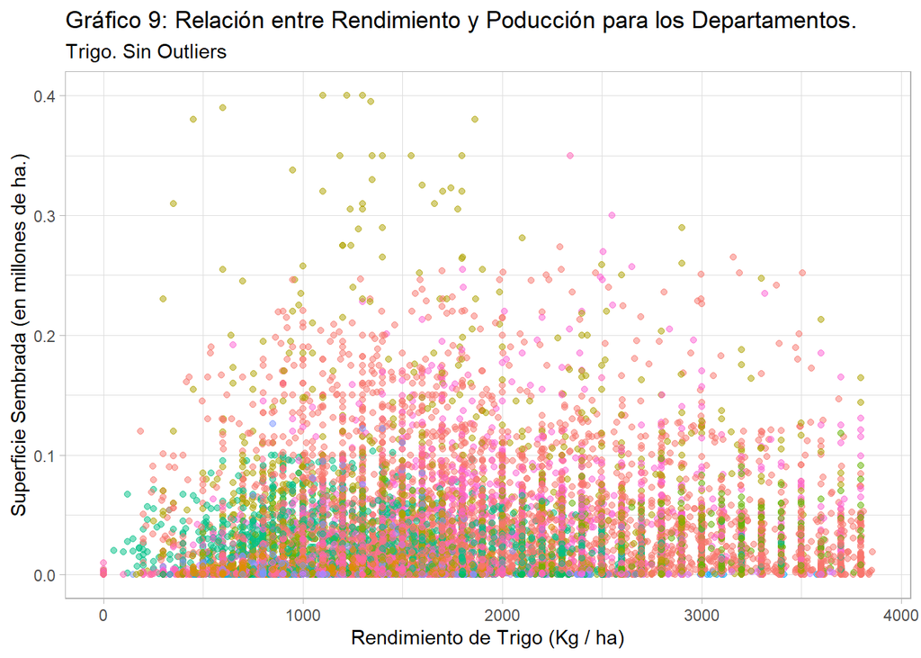

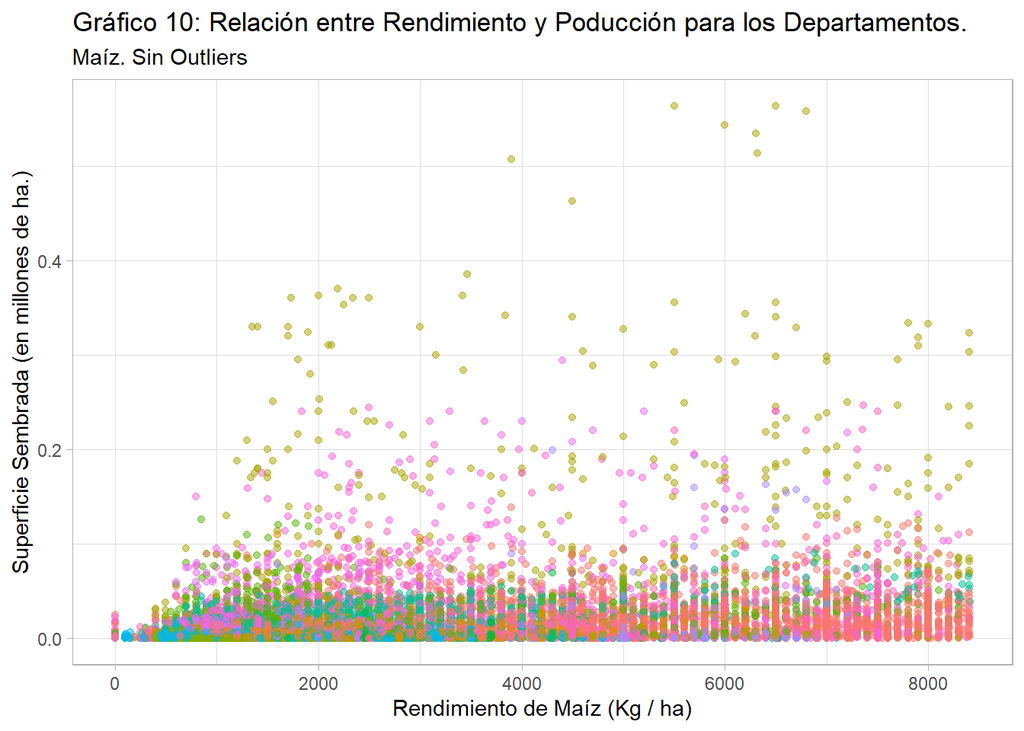

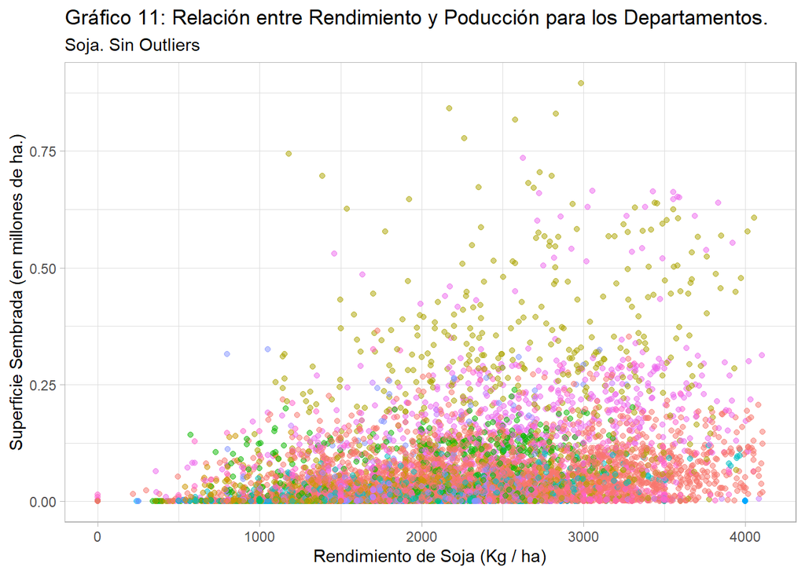

### Box Plots Rendimiento Sin Outliers.

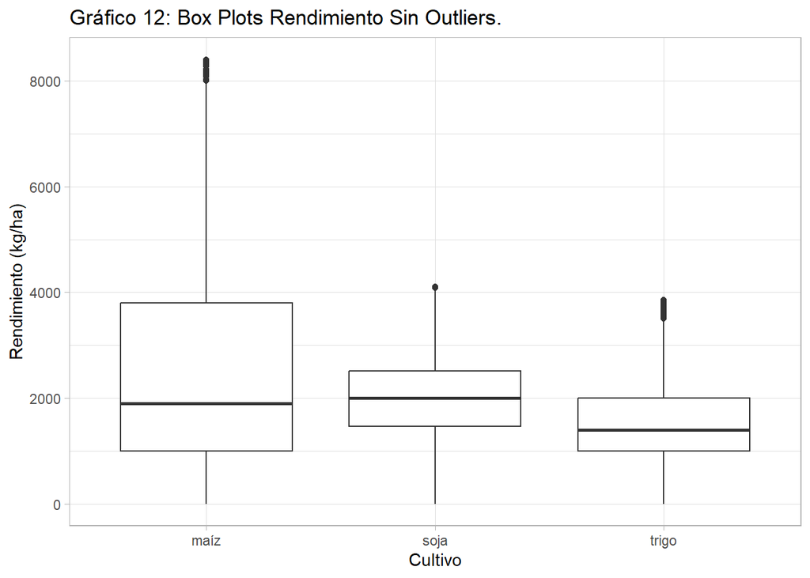

## Mapas

### Soja

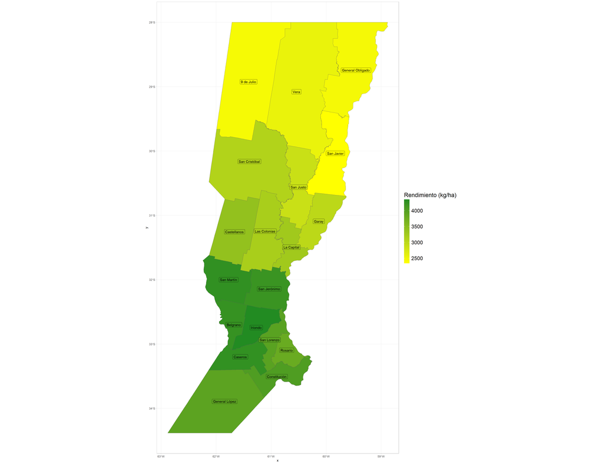

En la campaña 2018/2019 el departamento Iriondo se destaca con los mayores rindes de soja.

### Maíz

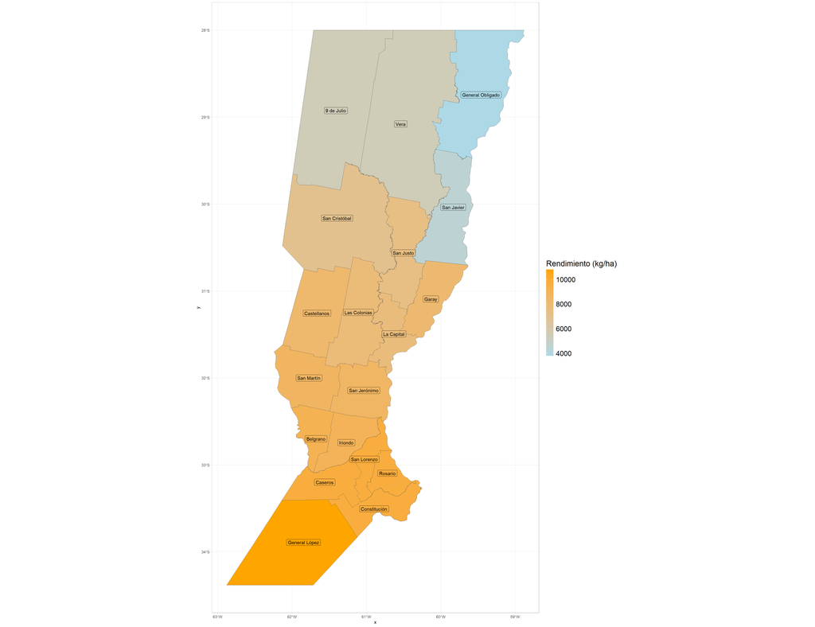

En el caso del maíz, el departamento General López tuvo los mejores rendimientos.

### Trigo

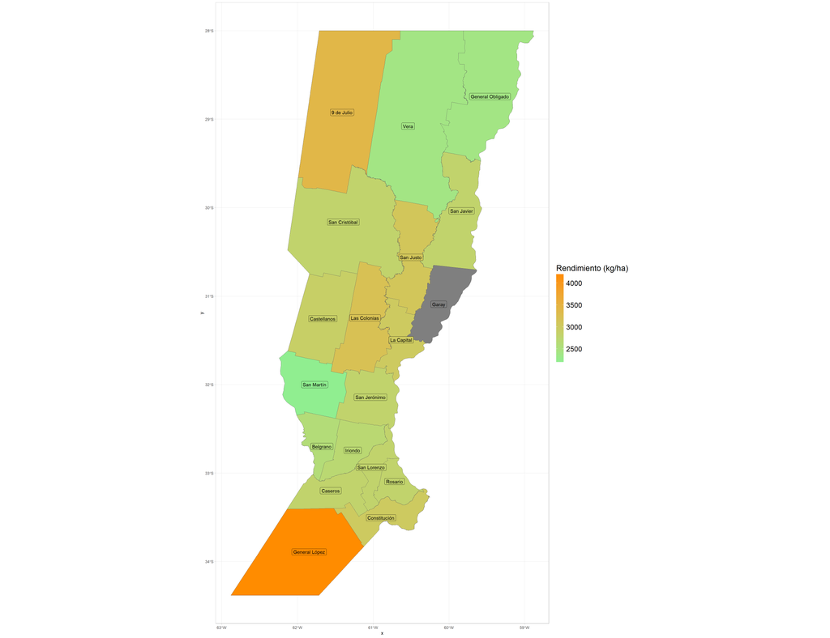

En el caso del trigo, tenemos los mismos resultados que para el Maíz, con General López destacado.

# Conclusión.

Dependiendo de las necesidades del organismo o empresa que pida este análisis se deberá profundizar en las distintas grillas o gráficos que se realizaron. Mejorar los mapas dependiendo de la zona de interes, revisar superficies particulares con sus rindes, etc.

Este pequeño análisis pretende dar un vistazo a vuelo de pájaro de lo que sucedió históricamente en el país y como le fue a los distintos departamentos de la provincia de Santa Fe en la mejor campaña de la historia.